# Exploratory Analyses 2

##### In Summary

Filtering out larger error_bins led to no real improvements in model $R^2$s, though of the *subsets* the 0-5 group often had better $R^2$s. Based on confidence intervals, there are no significant differences in parameter estiamtes between data including all observations and data including less uncertain coordinate estimates.

Using data from more precise error distances led to **increases in parameter estimate varaition (SE)**, especially for 0-2 km.

Lack of improvements may be due to loss of meaningful variation from records with greater uncertainty. Also, looking only at records with any error distance, there is a reduction in $R^2$ values.

[From old models]  
> Including error bin as a covariate (for models with 2+ bins) slightly increases $R^2$ but not parameter estimate (by much). For this reason, and the fact that uncertainty should have no direct effect on DOY, I’ve removed it. The significant effect of 2-5 km bin for error distance on DOY - slightly earlier - is likely due to chance.

> Filtering out records with larger error distances generally improves models, but improvements seem greatest for `MAT`, `Tmin` and `Tave`. `MAP`, `PPT_wt`, and `PPT_sp` models had larger parameter estimates for 0-2 km errors but Filtering finely to records with 0-2 km error led to larger parameter estimates, but at the cost of reduced R2 values and much larger SE. This could be due to a loss of variation and represents a trade-off to consider with future models. Oddly, a couple models with errors from 0-4 km were worse (for MAT, Tave_sp) than 0-2 or 0-5 error models. Model improvements were persistent when the error_bin covariate was removed from models, though R2 values were very slightly reduced.

In future models,  
- Consider treating error distance as a random effect? - Consider comparing all data with those with *errors from 0-5 km*

### Investigating the effect of manually georeferenced specimens on the relationship b/w DOY and climate variables

MAT & MAP

```r
#summary(an_lm_e) #nemo_df2
#summary(an_lm_ec) #with other covariates

an_lm_g1<- lm(DOY ~ MAT_100Y + MAP_100Y, data = nemo_geor)
an_lm_g1.1<- lm(DOY ~ MAT_100Y + MAP_100Y + elev_m + long + year, data = nemo_geor)
summary(an_lm_g1) #R2 = 0.2026 B = -2.38
```

```
##
## Call:
## lm(formula = DOY ~ MAT_100Y + MAP_100Y, data = nemo_geor)
##
## Residuals:
##     Min      1Q  Median      3Q     Max
## -74.781 -15.994  -0.306  16.276  91.697
##
## Coefficients:
##             Estimate Std. Error t value Pr(>|t|)
## (Intercept)  90.4973    32.0741   2.822  0.00499 **
## MAT_100Y     -3.1716     0.9551  -3.321  0.00097 ***
## MAP_100Y      8.5844     3.2073   2.677  0.00771 **
## ---
## Signif. codes:  0 '***' 0.001 '**' 0.01 '*' 0.05 '.' 0.1 ' ' 1
##
## Residual standard error: 27.16 on 455 degrees of freedom
## Multiple R-squared:  0.1089, Adjusted R-squared:  0.105
## F-statistic: 27.81 on 2 and 455 DF,  p-value: 4.029e-12
```

```r
summary(an_lm_g1.1)
```

```
##
## Call:
## lm(formula = DOY ~ MAT_100Y + MAP_100Y + elev_m + long + year,
##     data = nemo_geor)
##
## Residuals:
##     Min      1Q  Median      3Q     Max
## -72.268 -14.560   0.227  16.050  69.074
##
## Coefficients:
##               Estimate Std. Error t value Pr(>|t|)
## (Intercept) 397.197425 148.405241   2.676  0.00771 **
## MAT_100Y     -2.273597   1.099944  -2.067  0.03930 *
## MAP_100Y     14.427478   3.673958   3.927 9.95e-05 ***
## elev_m        0.018049   0.004282   4.215 3.02e-05 ***
## long          2.238302   1.090156   2.053  0.04063 *
## year         -0.049629   0.042282  -1.174  0.24111
## ---
## Signif. codes:  0 '***' 0.001 '**' 0.01 '*' 0.05 '.' 0.1 ' ' 1
##
## Residual standard error: 25.27 on 452 degrees of freedom
## Multiple R-squared:  0.2337, Adjusted R-squared:  0.2253
## F-statistic: 27.58 on 5 and 452 DF,  p-value: < 2.2e-16
```

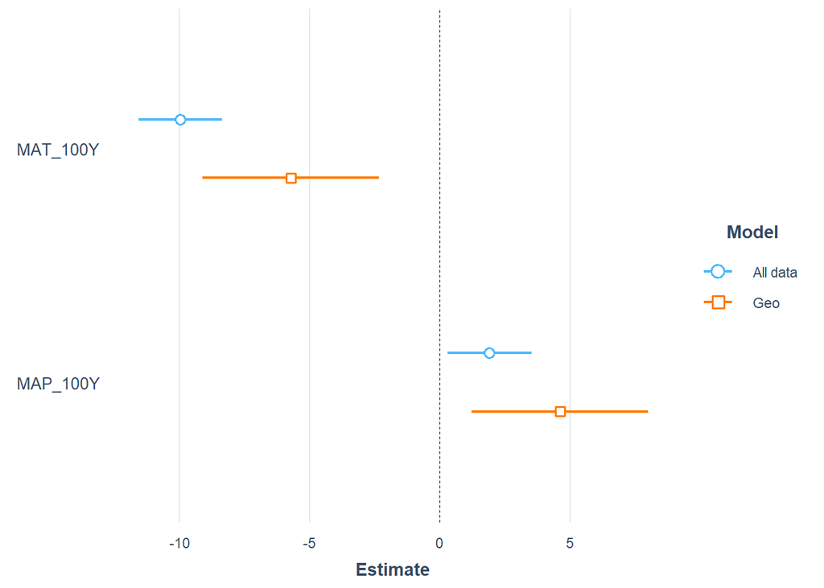

```r
plot_summs(an_lm_e, an_lm_g1, model.names = c("All data", "Geo"), scale = TRUE)
```

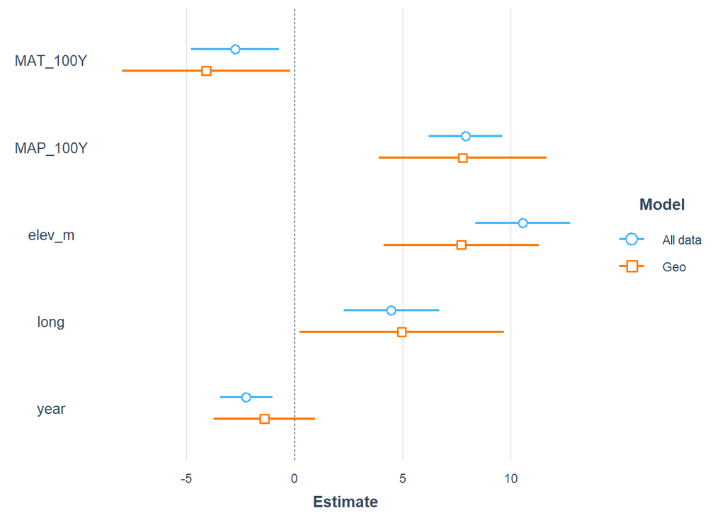

```r
plot_summs(an_lm_ec, an_lm_g1.1, model.names = c("All data", "Geo"), scale = TRUE)
```

From these averages it’s clear that subsetting by specimens we georeferenced increases variation in the parameter estiamte, as did subsetting by smaller error distances earlier.

What about data we did not georeference?

```
##
## Call:
## lm(formula = DOY ~ MAT_100Y + MAP_100Y, data = nemo_ngeo)
##
## Residuals:
##      Min       1Q   Median       3Q      Max
## -113.190  -17.465   -0.028   16.412  115.041
##
## Coefficients:
##             Estimate Std. Error t value Pr(>|t|)
## (Intercept) 176.3723    17.1439  10.288   <2e-16 ***
## MAT_100Y     -6.3518     0.5105 -12.441   <2e-16 ***
## MAP_100Y      3.7045     1.8555   1.997   0.0461 *
## ---
## Signif. codes:  0 '***' 0.001 '**' 0.01 '*' 0.05 '.' 0.1 ' ' 1
##
## Residual standard error: 27.03 on 1303 degrees of freedom
## Multiple R-squared:  0.1701, Adjusted R-squared:  0.1689
## F-statistic: 133.6 on 2 and 1303 DF,  p-value: < 2.2e-16
```

```
##
## Call:
## lm(formula = DOY ~ MAT_100Y + MAP_100Y + elev_m + long + year,
##     data = nemo_ngeo)
##
## Residuals:
##      Min       1Q   Median       3Q      Max
## -105.344  -14.765    0.172   14.882  148.660
##
## Coefficients:
##               Estimate Std. Error t value Pr(>|t|)
## (Intercept) 280.427189  78.750224   3.561 0.000383 ***
## MAT_100Y     -1.145854   0.697545  -1.643 0.100688
## MAP_100Y     15.274586   1.917836   7.964 3.59e-15 ***
## elev_m        0.024742   0.002784   8.886  < 2e-16 ***
## long          1.405048   0.537540   2.614 0.009056 **
## year         -0.053688   0.019334  -2.777 0.005567 **
## ---
## Signif. codes:  0 '***' 0.001 '**' 0.01 '*' 0.05 '.' 0.1 ' ' 1
##
## Residual standard error: 24.59 on 1300 degrees of freedom
## Multiple R-squared:  0.3149, Adjusted R-squared:  0.3122
## F-statistic: 119.5 on 5 and 1300 DF,  p-value: < 2.2e-16
```

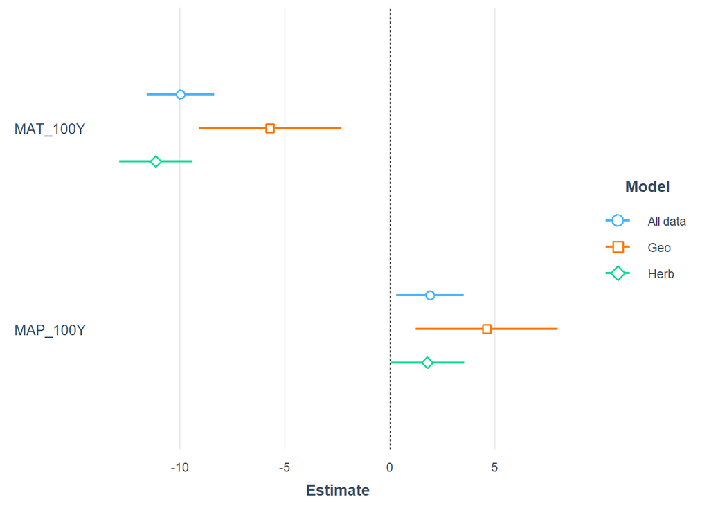

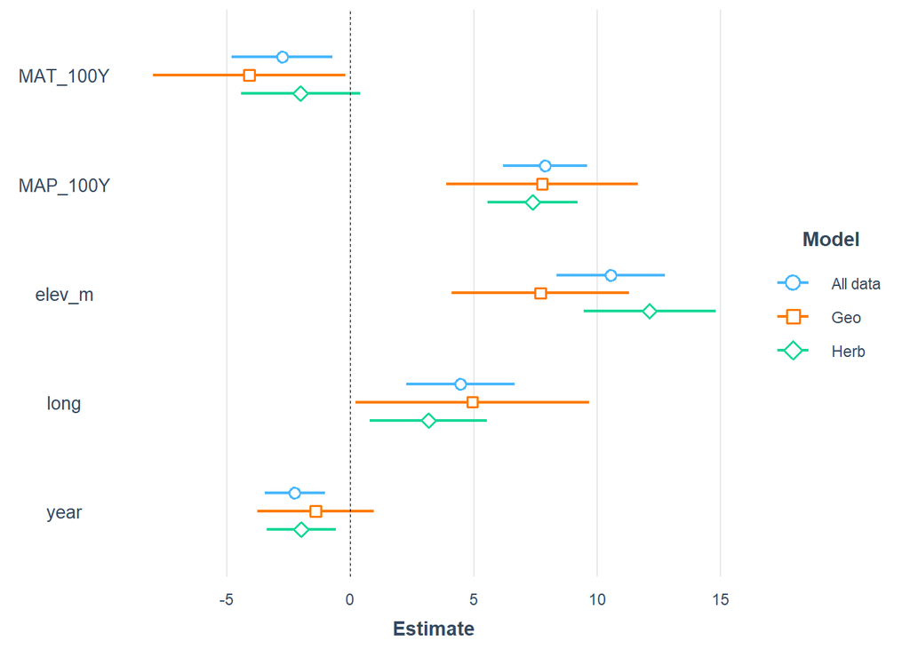

Ours still seem a little more variables (and NS in a couple cases), but are quite similar to herbarium-georeferenced data.

## EXPLORATORY ANALYSES - See ‘Climate_1.Rmd’ for more finalized analyses

### How does DOY depend on climate?

Note: The following parameter estimates of Precipitation variables on DOY are log-transformed and need to be back-transformed to be adequately interpreted.  
Note2: It is not necessary to include covariates for elev_m, lat/long, year if we’re mainly interested in the effect of climate variables on DOY…

#### Annual Climate

```r
MAT_lm1 <- lm(DOY ~ MAT_100Y + year + elev_m + lat, data = nemo_df1)
MAT_lm1.1 <- lm(DOY ~ MAT_100Y, data = nemo_df1)
summary(MAT_lm1) #R2 = .2646, MAT B = -2.53
summary(MAT_lm1.1)

MAP_lm1 <- lm(DOY ~ MAP_100Y + year + elev_m + lat, data = nemo_df1)
MAP_lm1.1 <- lm(DOY ~ MAP_100Y, data = nemo_df1)
summary(MAP_lm1)#R2 = .2894, MAP B = 14.6
summary(MAP_lm1.1)


ann_lm1 <- lm(DOY ~ MAT_100Y + MAP_100Y + long + elev_m + year, data = nemo_df2)
ann_lm1.1 <- lm(DOY ~ MAT_100Y + MAP_100Y, data = nemo_df2)
summary(ann_lm1) #R2 = .2989 #MAT estimate is much lower than in first lm (MAP slightly lower)
summary(ann_lm1.1)
#MAT NS if nemo_df1 is used
#MAP and MAT somewhat correlated (r = -.58) but no interaction present

ann_lm1.2 <- lm(DOY ~ MAT_Y + MAP_Y, data = nemo_df2)
summary(ann_lm1.2)
```

```r
summary(ann_lm1.1)
```

```
##
## Call:
## lm(formula = DOY ~ MAT_100Y + MAP_100Y, data = nemo_df2)
##
## Residuals:
##     Min      1Q  Median      3Q     Max
## -92.411 -17.273  -1.012  16.576 118.874
##
## Coefficients:
##             Estimate Std. Error t value Pr(>|t|)
## (Intercept) 163.2975    15.2966  10.675   <2e-16 ***
## MAT_100Y     -5.5855     0.4598 -12.148   <2e-16 ***
## MAP_100Y      3.7348     1.6079   2.323   0.0203 *
## ---
## Signif. codes:  0 '***' 0.001 '**' 0.01 '*' 0.05 '.' 0.1 ' ' 1
##
## Residual standard error: 27.11 on 1674 degrees of freedom
## Multiple R-squared:  0.1461, Adjusted R-squared:  0.1451
## F-statistic: 143.2 on 2 and 1674 DF,  p-value: < 2.2e-16
```

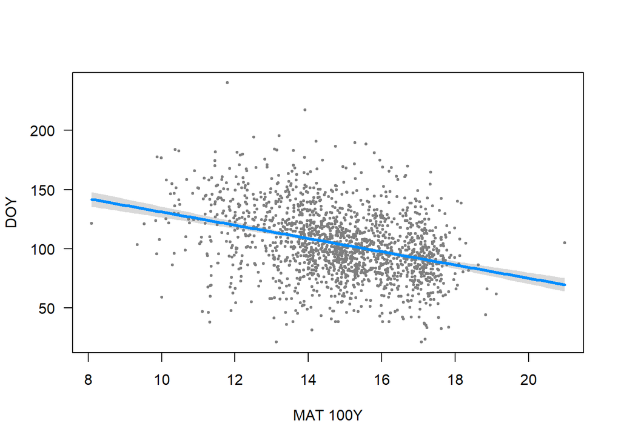

```r
visreg(ann_lm1.1, "MAT_100Y", xlab = "MAT 100Y")
```

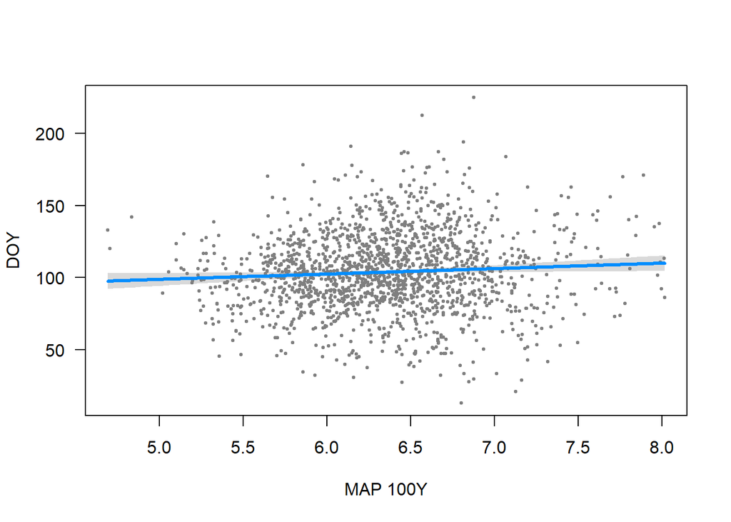

```r
visreg(ann_lm1.1, "MAP_100Y", xlab = "MAP 100Y")
```

```r
summary(ann_lm1.2)
```

```
##
## Call:
## lm(formula = DOY ~ MAT_Y + MAP_Y, data = nemo_df2)
##
## Residuals:
##     Min      1Q  Median      3Q     Max
## -90.528 -17.257  -0.605  17.366 115.127
##
## Coefficients:
##             Estimate Std. Error t value Pr(>|t|)
## (Intercept) 154.0500    12.5506  12.274  < 2e-16 ***
## MAT_Y        -5.0529     0.4074 -12.404  < 2e-16 ***
## MAP_Y         4.1384     1.2888   3.211  0.00135 **
## ---
## Signif. codes:  0 '***' 0.001 '**' 0.01 '*' 0.05 '.' 0.1 ' ' 1
##
## Residual standard error: 27.07 on 1674 degrees of freedom
## Multiple R-squared:  0.1484, Adjusted R-squared:  0.1474
## F-statistic: 145.8 on 2 and 1674 DF,  p-value: < 2.2e-16
```

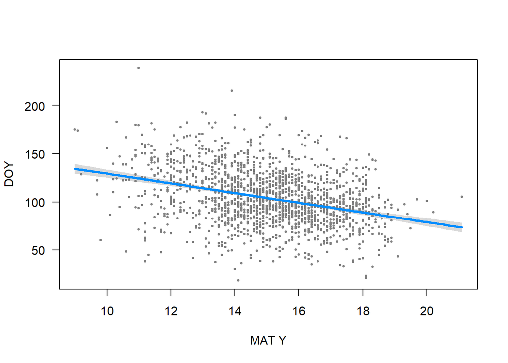

```r
visreg(ann_lm1.2, "MAT_Y", xlab = "MAT Y")
```

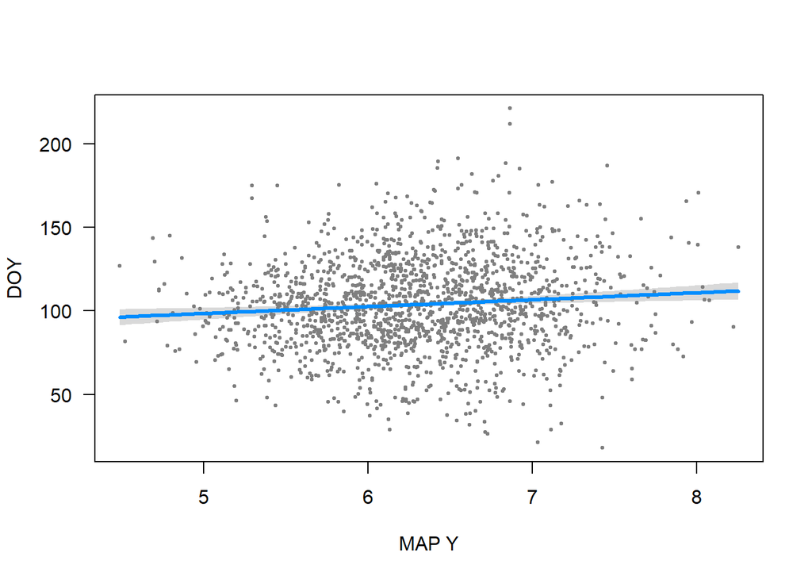

```r
visreg(ann_lm1.2, "MAP_Y", xlab = "MAP Y")
```

```r
#Analyses w normals not shown
#R2 highest (and coeffs most -) for 100Y avg climate - use it for long term avg.
```

[output not shown]

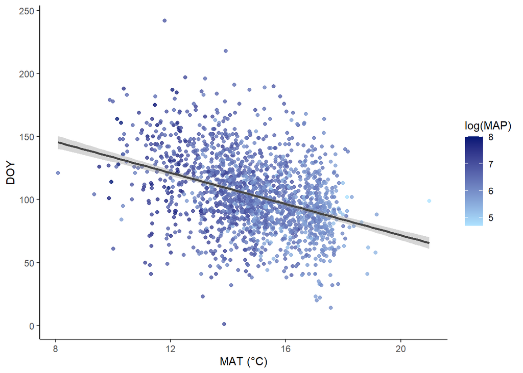

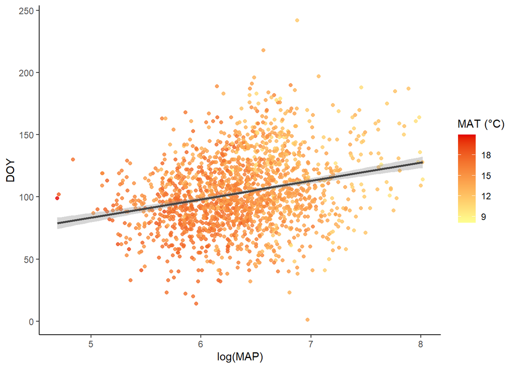

MAT predicts advanced DOY, MAP predicts delayed DOY.

Elevation and MAP/MAT appear to have the most significant effects on DOY.

MAT

```r
#100Y
MAT_m0 <- lm(DOY ~ MAT_100Y, data = nemo_df1)
MAT_m1 <- lm(DOY ~ MAT_100Y + elev_m, data = nemo_df1)
MAT_m1.1 <- lm(DOY ~ MAT_100Y + elev_m, data = nemo_df2)
MAT_m1.2 <- lm(DOY ~ MAT_100Y + elev_m, data = nemo_e0_5) #Best
summary(MAT_m1)
summary(MAT_m1.1)
summary(MAT_m1.2) #or summ(MAT_m1.2, vifs =  TRUE)
#0-5 km model best, df1 and df2 similar

#Anomalies...

#YoC
MAT_m2.2 <- lm(DOY ~ MAT_Y + elev_m, data = nemo_e0_5)
summary(MAT_m2.2)

#plot_summs(MAT_m1, MAT_m1.1, MAT_m1.2, MAT_m2.2, scale = TRUE, coefs = c("MAT (1901-2000)" = "MAT_100Y", "MAT (YoC)" = "MAT_Y", "Elevation (m)" = "elev_m"), model.names = c("All records", "Records 1901-2019", "Errors 0-5 km", "YoC 0-5 km"), legend.title = expression('Model')) #Same pattern with YoC climate
```

MWMT & MCMT

```r
#100Y
MW_m0 <- lm(DOY ~ MWMT_100Y, data = nemo_df1)
MW_m1 <- lm(DOY ~ MWMT_100Y + elev_m + lat, data = nemo_df1)
MW_m1.1 <- lm(DOY ~ MWMT_100Y + elev_m + lat, data = nemo_df2)
MW_m1.2 <- lm(DOY ~ MWMT_100Y + elev_m + lat, data = nemo_e0_5) #Better
summary(MW_m1)
summary(MW_m1.1)
summary(MW_m1.2)

MC_m0 <- lm(DOY ~ MCMT_100Y, data = nemo_df1)
MC_m1 <- lm(DOY ~ MCMT_100Y + elev_m + lat, data = nemo_df1) #barely better, all similar
MC_m1.1 <- lm(DOY ~ MCMT_100Y + elev_m + lat, data = nemo_df2)
MC_m1.2 <- lm(DOY ~ MCMT_100Y + elev_m + lat, data = nemo_e0_5)
summary(MC_m1)
summary(MC_m1.1)
summary(MC_m1.2)
```

DD > 5

```r
#100Y
dd5_m0 <- lm(DOY ~ DD5_100Y, data = nemo_df1)
dd5_m1 <- lm(DOY ~ DD5_100Y + elev_m, data = nemo_df1)
dd5_m1.1 <- lm(DOY ~ DD5_100Y + elev_m, data = nemo_df2)
dd5_m1.2 <- lm(DOY ~ DD5_100Y + elev_m, data = nemo_e0_5) #better
##DD5 correlated w/ MAT
#lat first included, but ns

summary(dd5_m1)
summary(dd5_m1.1)
summary(dd5_m1.2)
```

NFFD

```r
#100Y
ffd_m1 <- lm(DOY ~ NFFD_100Y + elev_m + lat, data = nemo_df1)
ffd_m1.1 <- lm(DOY ~ NFFD_100Y + elev_m + lat, data = nemo_df2)
ffd_m1.2 <- lm(DOY ~ NFFD_100Y + elev_m + lat, data = nemo_e0_5) #same as 1, but best estimate

summary(ffd_m1)
summary(ffd_m1.1)
summary(ffd_m1.2)
visreg(ffd_m1.2, "NFFD_100Y")

#NFFD might need a transformation...
```

MAP, MSP

```r
#100Y
MAP_m1 <- lm(DOY ~ MAP_100Y + elev_m + long, data = nemo_df1) #Good
MAP_m1.1 <- lm(DOY ~ MAP_100Y + elev_m + long, data = nemo_df2) #Better
MAP_m1.2 <- lm(DOY ~ MAP_100Y + elev_m + long, data = nemo_e0_5)

summary(MAP_m1)
summary(MAP_m1.1)
summary(MAP_m1.2)
#Long more significant than lat, higher R2


#MSP

#
#100Y
MSP_m1 <- lm(DOY ~ MSP_100Y + elev_m, data = nemo_df1)
MSP_m1.1 <- lm(DOY ~ MSP_100Y + elev_m, data = nemo_df2)
MSP_m1.2 <- lm(DOY ~ MSP_100Y + elev_m, data = nemo_e0_5)
#Long does not significant here
#Models all very similar

summary(MSP_m1)
summary(MSP_m1.1)
summary(MSP_m1.2)
```

CMD, RH

```r
#100Y
#RH ALL ns at the annual, 100Y scale

#CMD
#100Y
cmd_m0 <- lm(DOY ~ CMD_100Y, data = nemo_df1)
cmd_m1 <- lm(DOY ~ CMD_100Y + elev_m, data = nemo_df1)
cmd_m1.1<- lm(DOY ~ CMD_100Y + elev_m, data = nemo_df2) #slightly higher estimate
cmd_m1.2 <- lm(DOY ~ CMD_100Y + elev_m, data = nemo_e0_5) #better but not by much

summary(cmd_m1)
summary(cmd_m1.1)
summary(cmd_m1.2)
```

AHM (SHM)

```r
#AHM
#100Y
ahm_m0 <- lm(DOY ~ AHM_100Y, data = nemo_df1)
ahm_m1 <- lm(DOY ~ AHM_100Y + elev_m, data = nemo_df1)
ahm_m1.1<- lm(DOY ~ AHM_100Y + elev_m, data = nemo_df2)
ahm_m1.2 <- lm(DOY ~ AHM_100Y + elev_m, data = nemo_e0_5) #better
#Pretty correlated to temp, dd>5

summary(ahm_m1)
summary(ahm_m1.1)
summary(ahm_m1.2)

#SHM not as significant as AHM
```

**Seasonal Variables**

##### Temperature

```r
#Tmin
Tmin_wt_lm1 <- lm(DOY ~ Tmin_wt_100Y + PPT_wt_100Y + Tmin_wt_100Y*PPT_wt_100Y, data = nemo_df1)
summary(Tmin_wt_lm1) ##significant interaction

Tmin_sp_lm1 <- lm(DOY ~ Tmin_sp_100Y + PPT_sp_100Y + Tmin_sp_100Y*PPT_sp_100Y, data = nemo_df1)
summary(Tmin_sp_lm1) #R2 = .2677 B = -2.57

Tmin_sm_lm1 <- lm(DOY ~ Tmin_sm_100Y + year + elev_m + lat, data = nemo_df1)
summary(Tmin_sm_lm1) #R2 = .265 B = -1.64



#Tave
Tave_wt_lm1 <- lm(DOY ~ Tave_wt_100Y + year + elev_m + lat, data = nemo_df1)
summary(Tave_wt_lm1) #ns

Tave_sp_lm1 <- lm(DOY ~ Tave_sp_100Y + year + elev_m + lat, data = nemo_df1)
summary(Tave_sp_lm1) # R = .2724 B = -3.58  #lat ns here

Tave_sm_lm1 <- lm(DOY ~ Tave_sm_100Y + year + elev_m + lat, data = nemo_df1)
summary(Tave_sm_lm1) #R2 = .263 B = -1.15

#Tmax
Tmax_sp_lm1 <- lm(DOY ~ Tmax_sp_100Y + year + elev_m + lat, data = nemo_df1)
summary(Tmax_sp_lm1) #R2 = .2609 B = -1.42
```

```r
visreg(Tmin_sp_lm1, "Tmin_sp_100Y")
```

```
## Conditions used in construction of plot
## PPT_sp_100Y: 5.030111
```

[figure not shown]

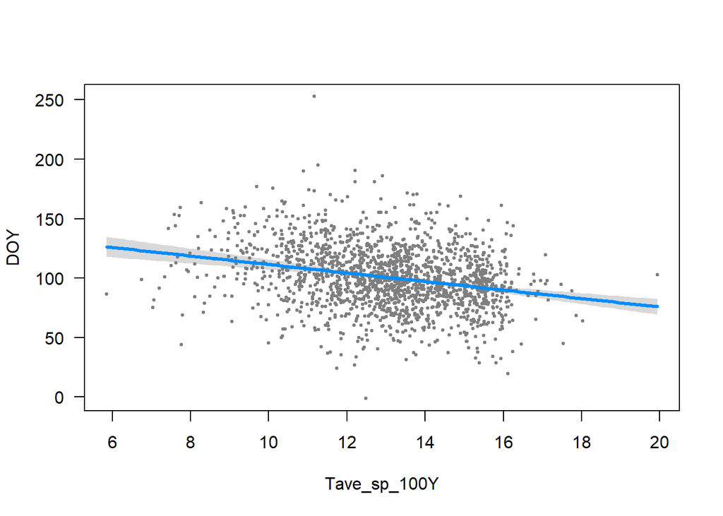

```r
visreg(Tave_sp_lm1, "Tave_sp_100Y")
```

##### PPT

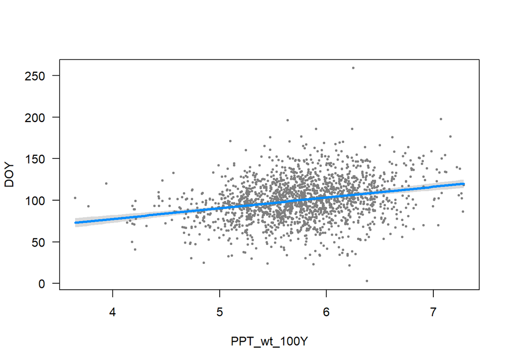

```r
#PPT
PPT_wt_lm1 <- lm(DOY ~ PPT_wt_100Y + year + elev_m + lat, data = nemo_df1) #log transform PPT? here or in df?
summary(PPT_wt_lm1) #R2 = .2853 B = 12.88
visreg(PPT_wt_lm1, "PPT_wt_100Y")
```

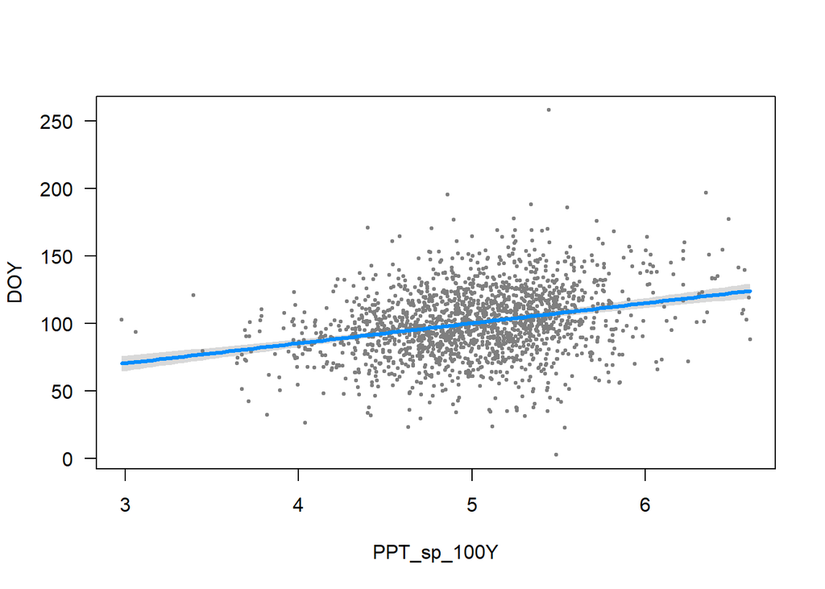

```r
PPT_sp_lm1 <- lm(DOY ~ PPT_sp_100Y + year + elev_m + lat, data = nemo_df1)
summary(PPT_sp_lm1) #R2 = .2929 B = 14.87   #lat ns #preferred model?
visreg(PPT_sp_lm1, "PPT_sp_100Y")
```

```r
PPT_sm_lm1 <- lm(DOY ~ PPT_sm_100Y + year + elev_m + lat, data = nemo_df1, na.action = na.omit)
summary(PPT_sm_lm1) #R2 = .2668 B = 5.01
#var. in PPT much lower than for spring and witner
```

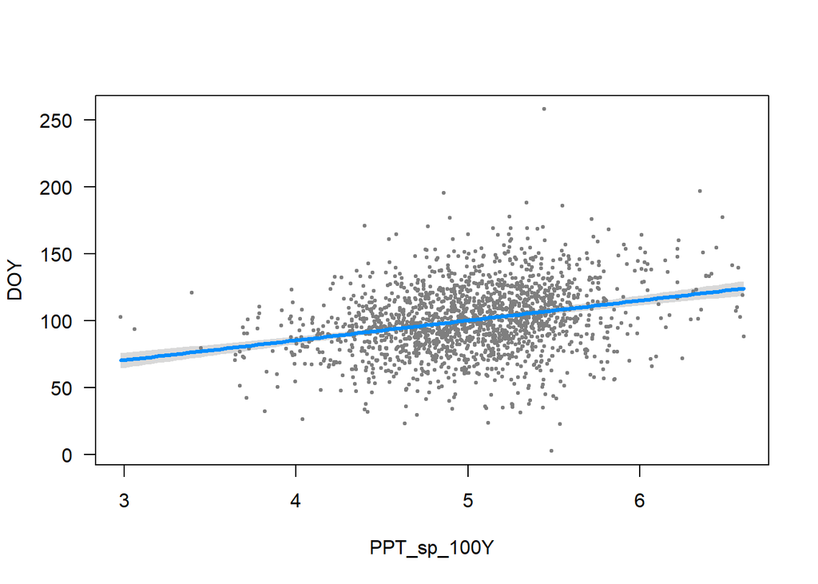

```r
PPT_sp_lm1 <- lm(DOY ~ PPT_sp_100Y + year + elev_m + lat, data = nemo_df1)
#summary(PPT_sp_lm1)  #R2 = .2929 B = 14.87
visreg(PPT_sp_lm1, "PPT_sp_100Y")
```

**In Summary**

DOY is sensitive to both MAT (advancing effect) and MAP (delaying effect) over 100 years, and precipitation may be just as stronger, or even stronger, than MAT.

Spring temperatures (particularly Tave and also Tmin) explain more variation and have larger estimates in their relationship with DOY than winter temperatures.